# SSAMethodCode

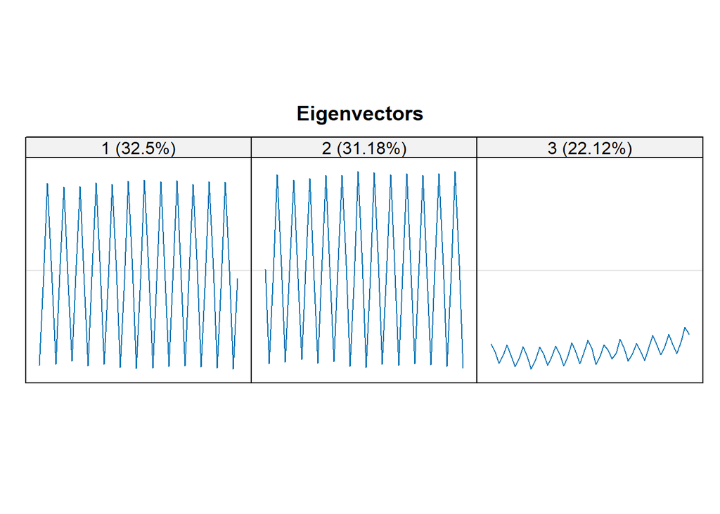

```r
s.TSExample <- ssa(TSExample[1:100])
r.TSExample <- reconstruct(s.TSExample)
plot(s.TSExample, type='vectors', idx=1:3)
```

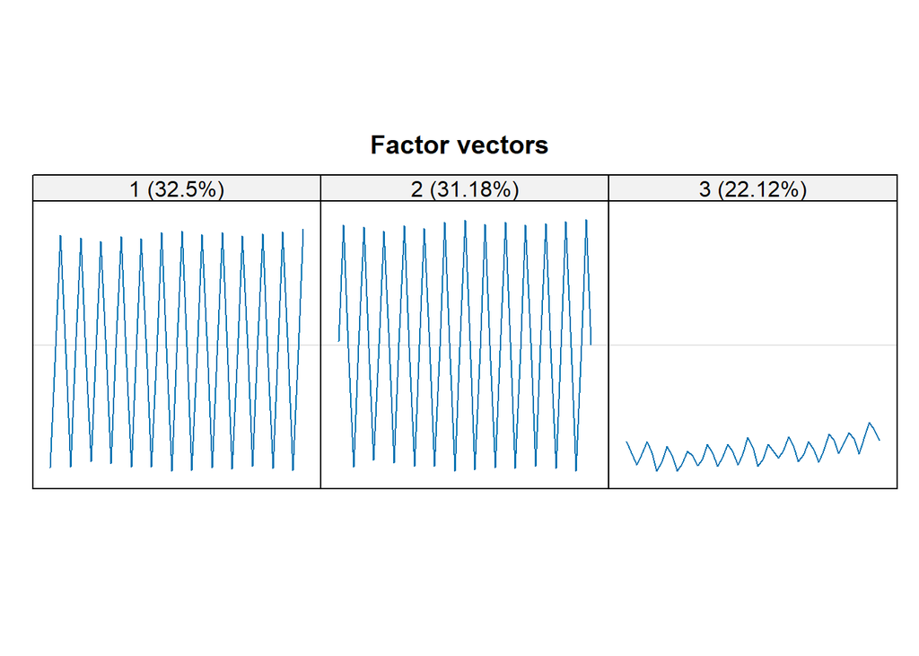

```r
plot(s.TSExample, type='vectors', vectors='factor', idx=1:3)
```

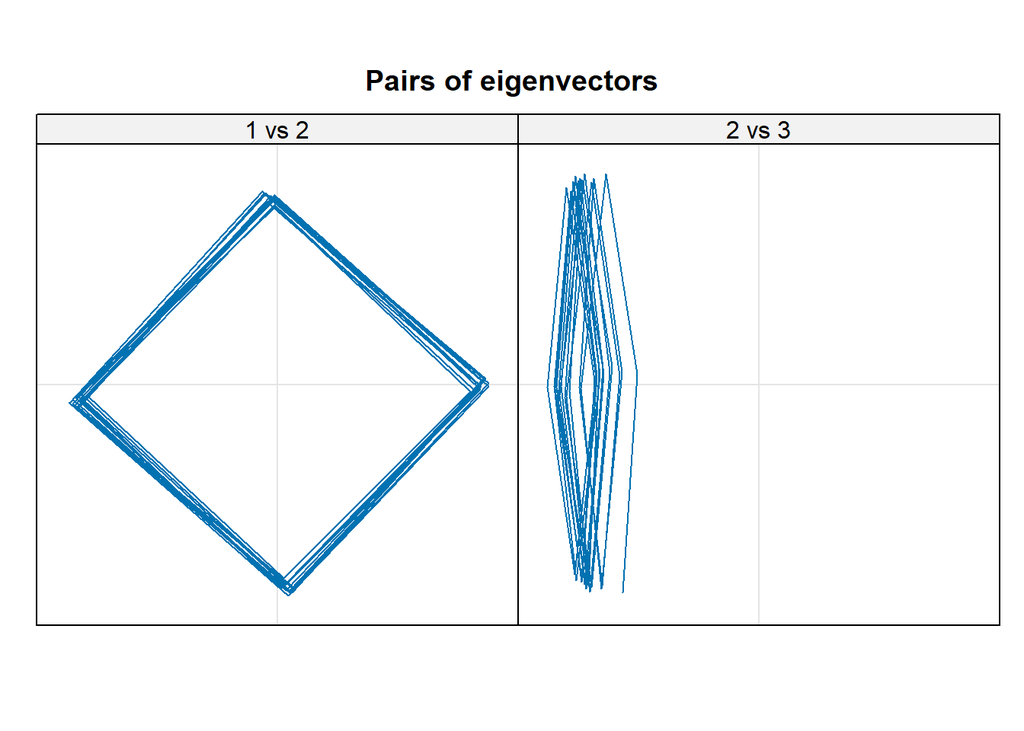

```r
plot(s.TSExample, type='paired', idx=1:2, plot.contrib = FALSE)
```

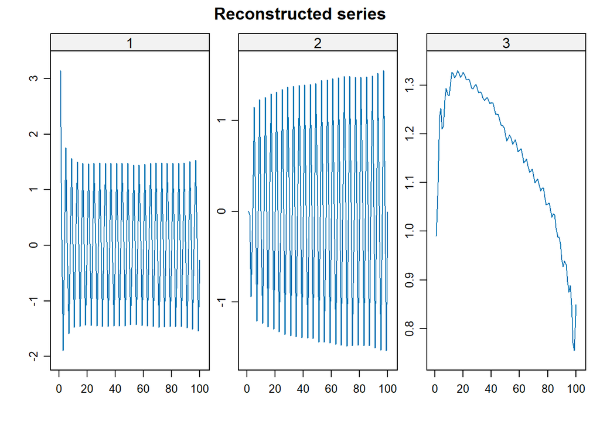

```r
plot(s.TSExample, type='series', groups=1:3)
```

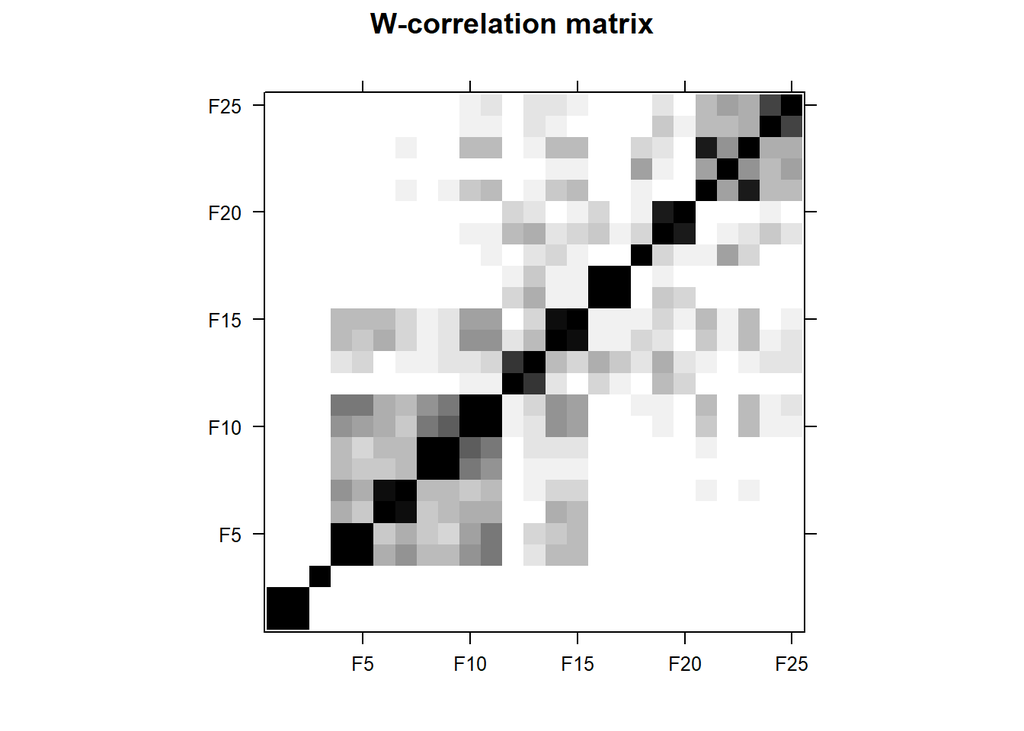

```r
plot(wcor(s.TSExample, groups=1:25), scales=list(at=seq(5,25,5)))
```

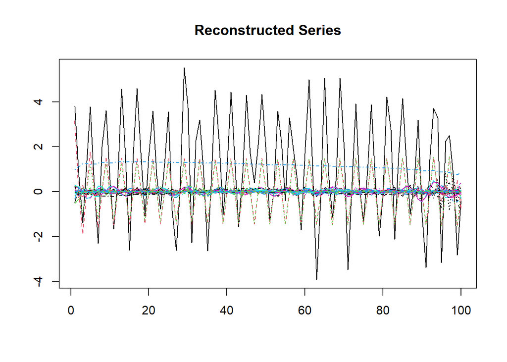

```r
plot(r.TSExample)
```

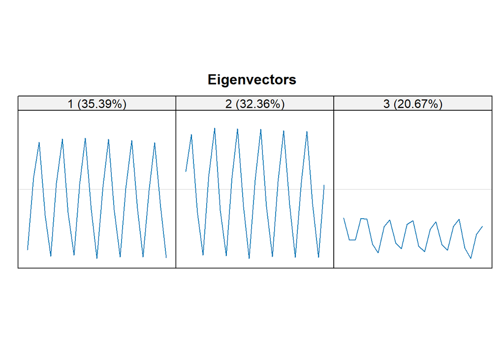

```r
s.TSExample <- ssa(TSExample[1:50])
r.TSExample <- reconstruct(s.TSExample)
plot(s.TSExample, type='vectors', idx=1:3)
```

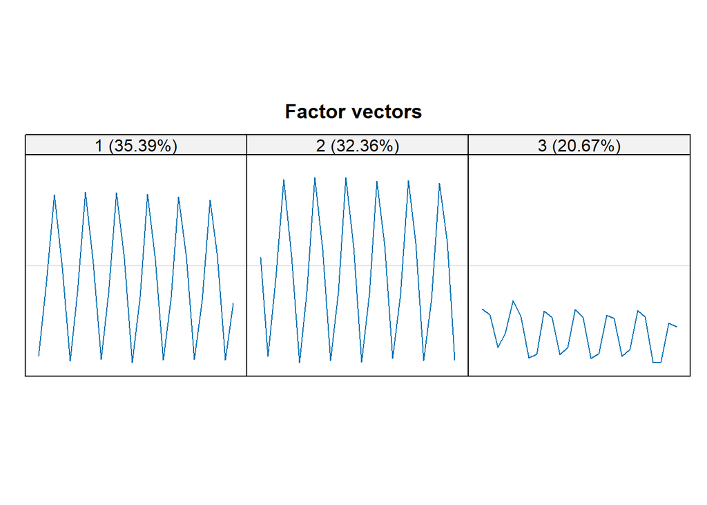

```r
plot(s.TSExample, type='vectors', vectors='factor', idx=1:3)
```

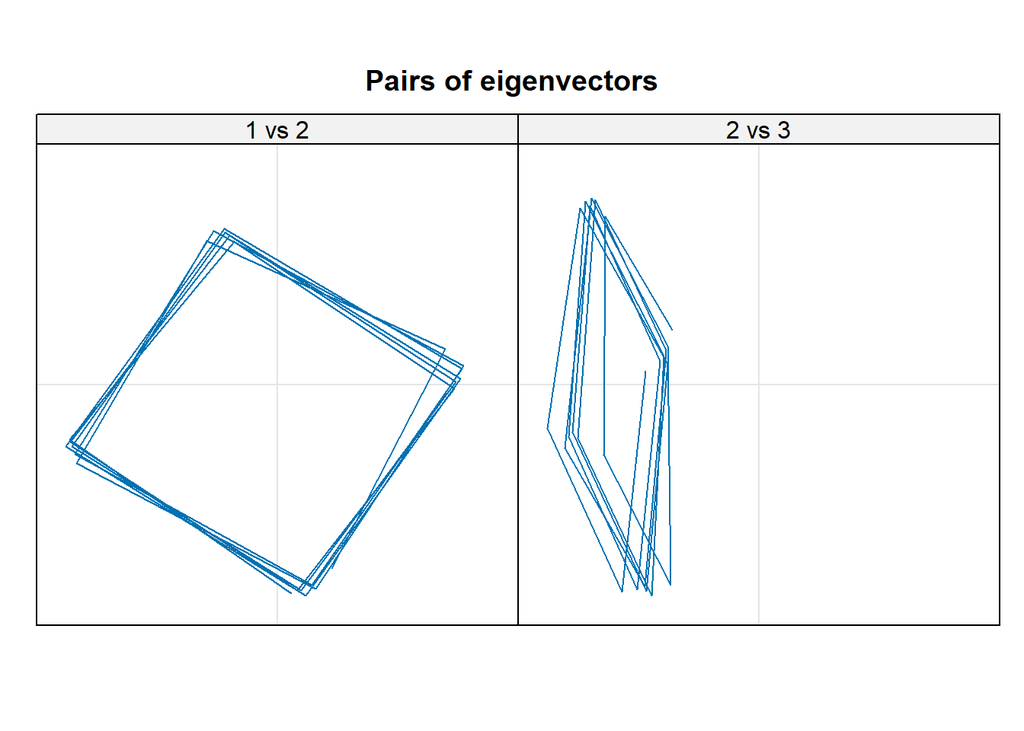

```r
plot(s.TSExample, type='paired', idx=1:2, plot.contrib = FALSE)
```

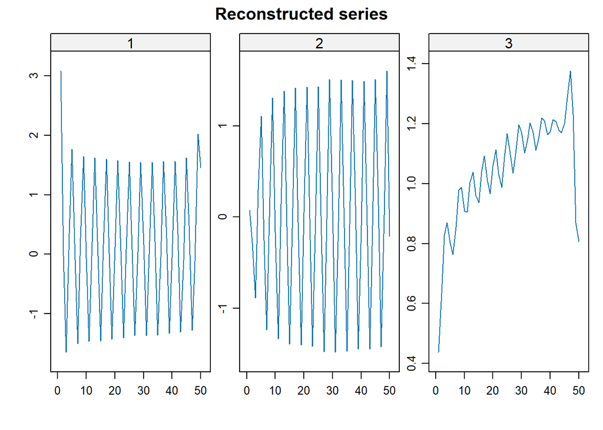

```r
plot(s.TSExample, type='series', groups=1:3)
```

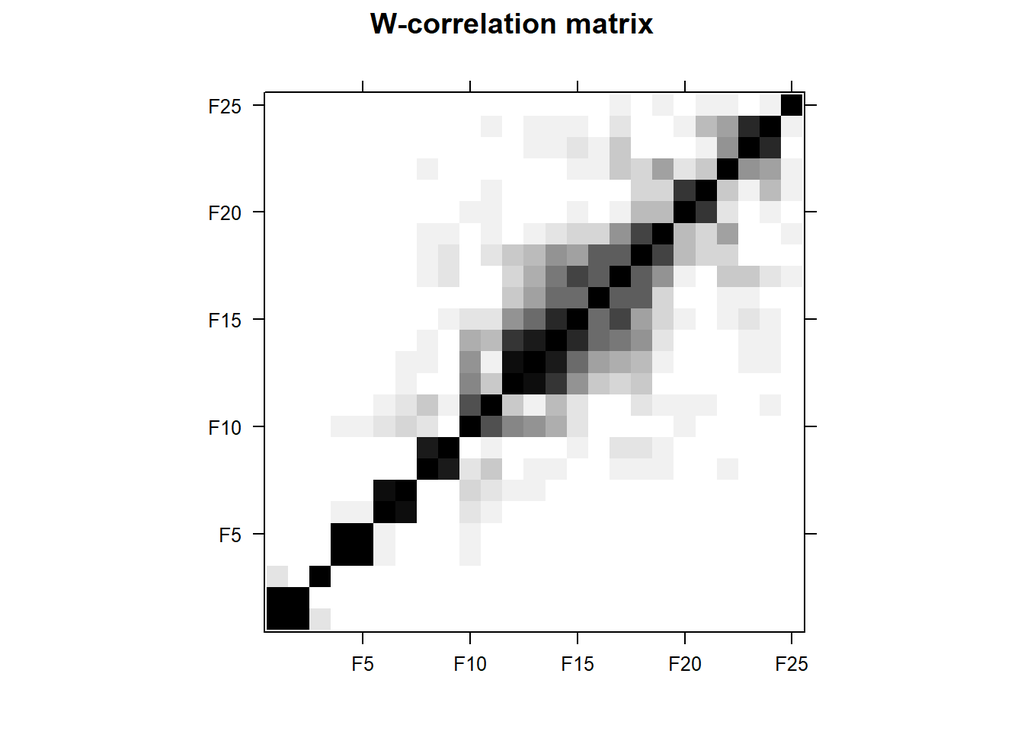

```r
plot(wcor(s.TSExample, groups=1:25), scales=list(at=seq(5,25,5)))
```

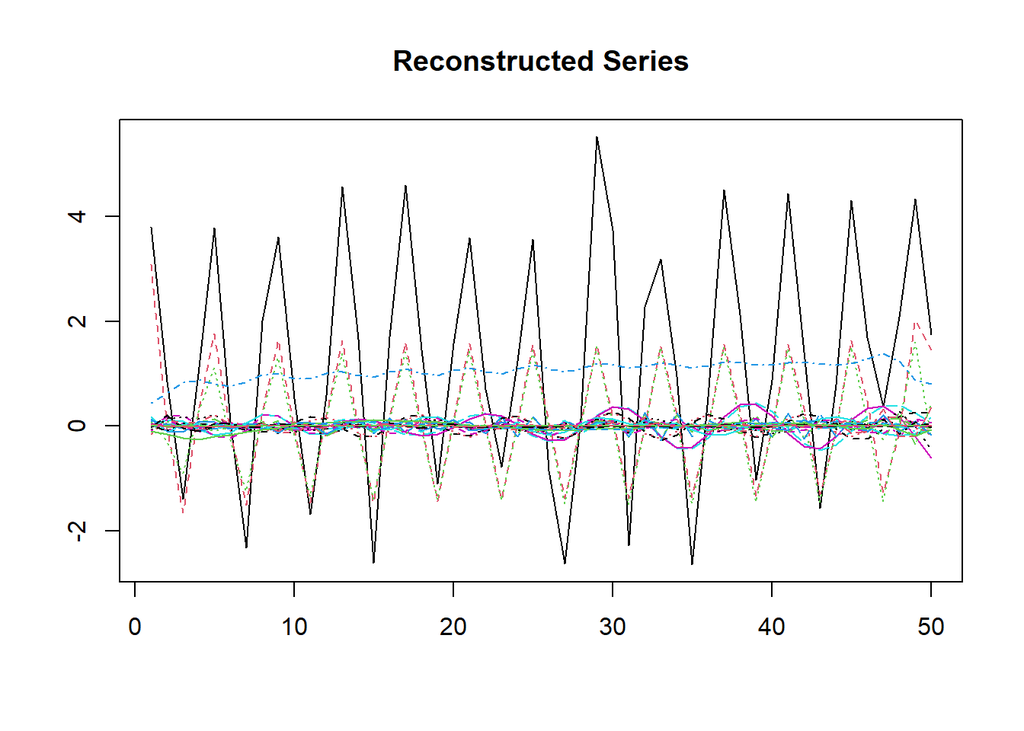

```r
plot(r.TSExample)
```

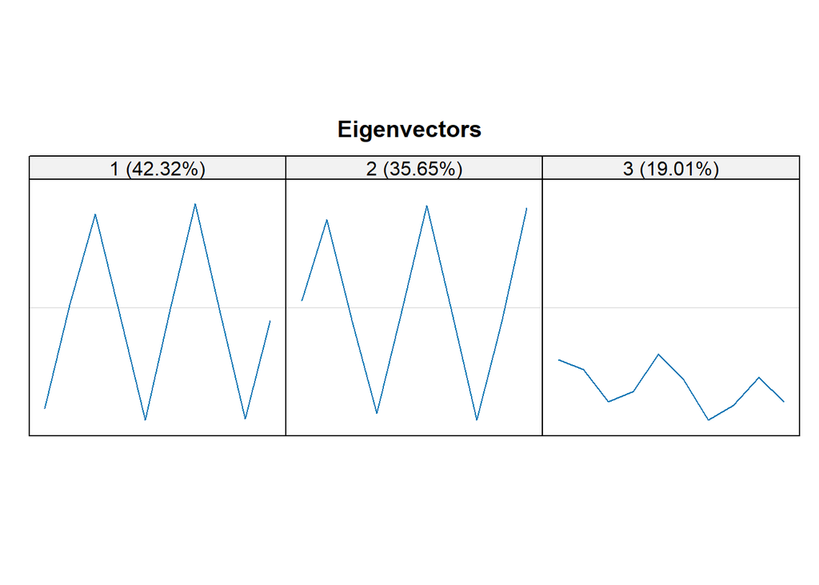

```r
s.TSExample <- ssa(TSExample[1:20])
r.TSExample <- reconstruct(s.TSExample)
plot(s.TSExample, type='vectors', idx=1:3)
```

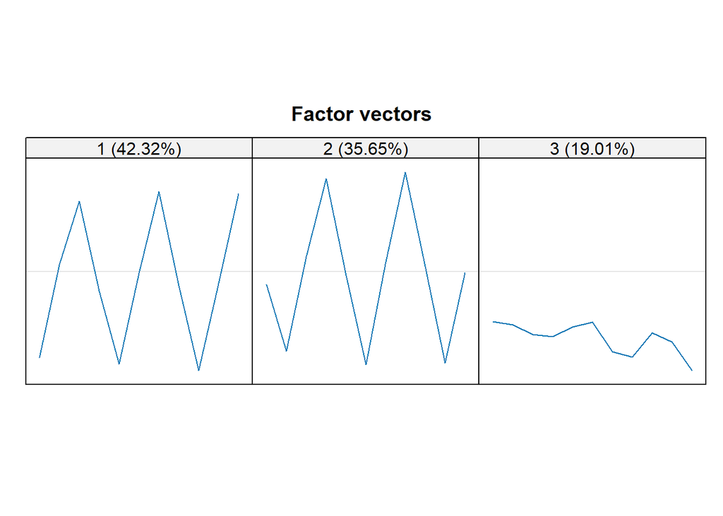

```r
plot(s.TSExample, type='vectors', vectors='factor', idx=1:3)
```

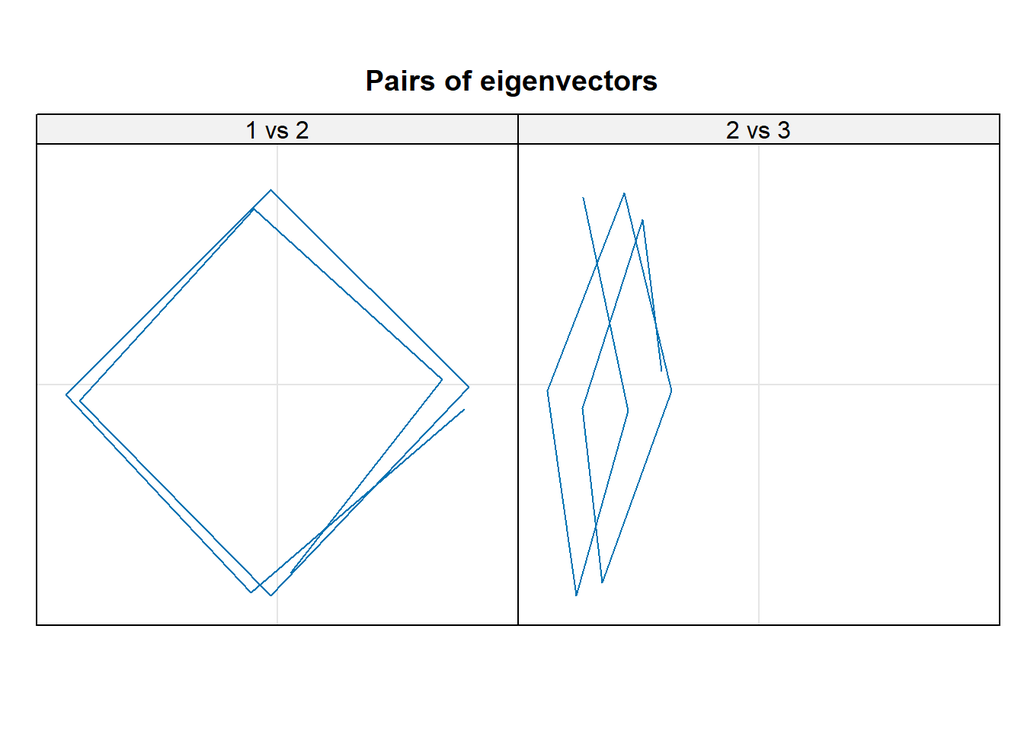

```r
plot(s.TSExample, type='paired', idx=1:2, plot.contrib = FALSE)
```

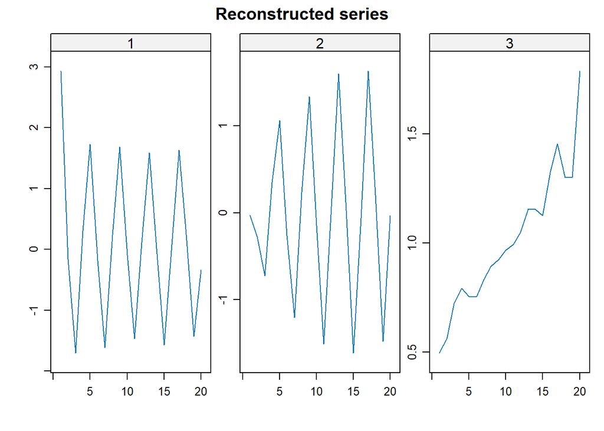

```r
plot(s.TSExample, type='series', groups=1:3)
```

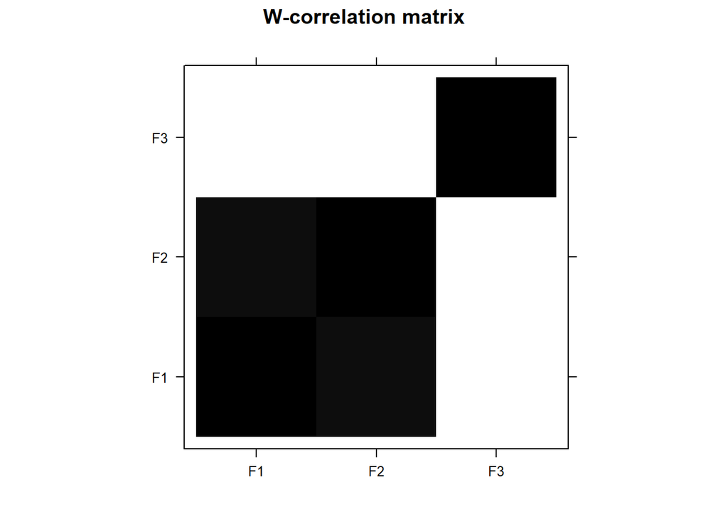

```r
plot(wcor(s.TSExample, groups=1:3))
```

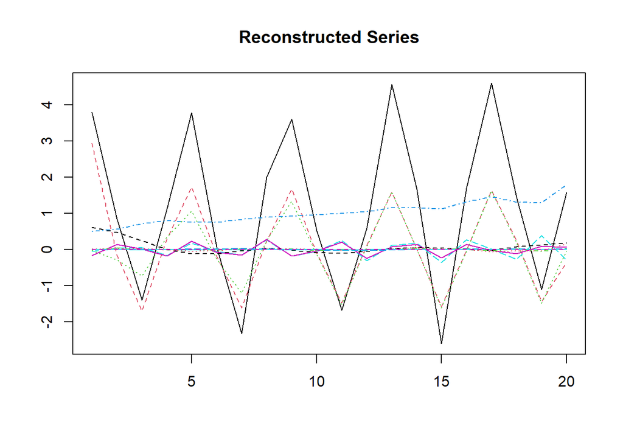

```r
plot(r.TSExample)
```

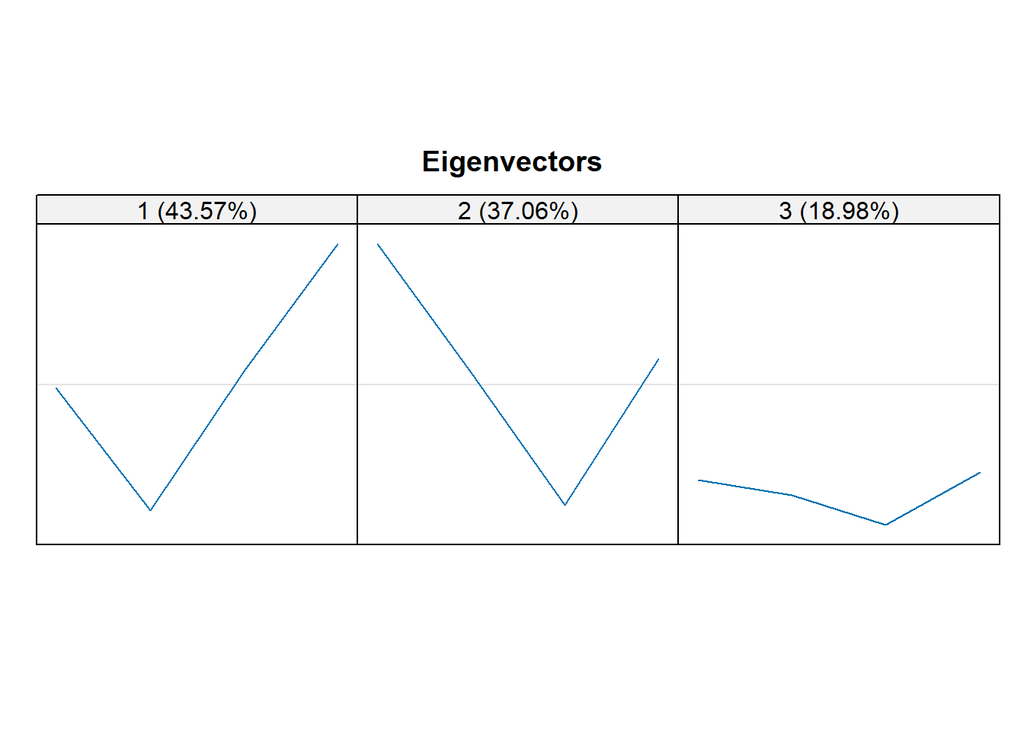

```r
s.TSExample <- ssa(TSExample[1:7])
r.TSExample <- reconstruct(s.TSExample)
plot(s.TSExample, type='vectors', idx=1:3)
```

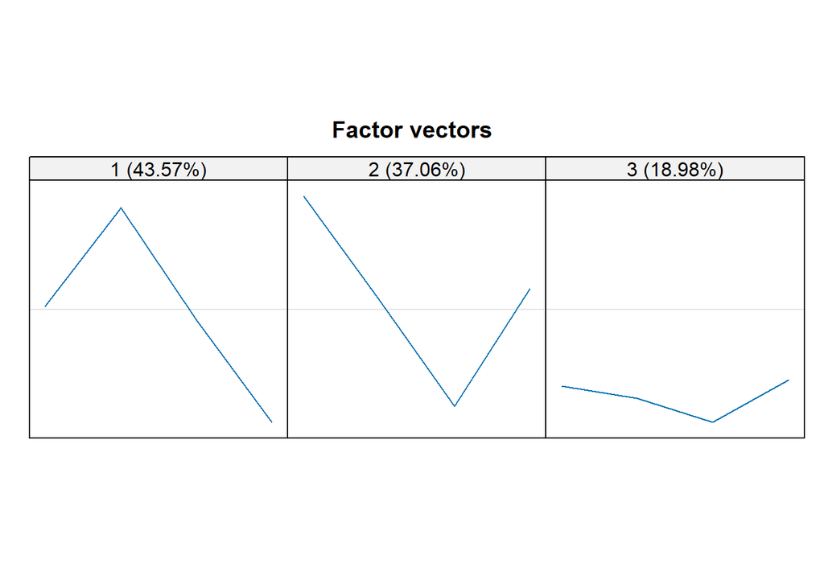

```r
plot(s.TSExample, type='vectors', vectors='factor', idx=1:3)
```

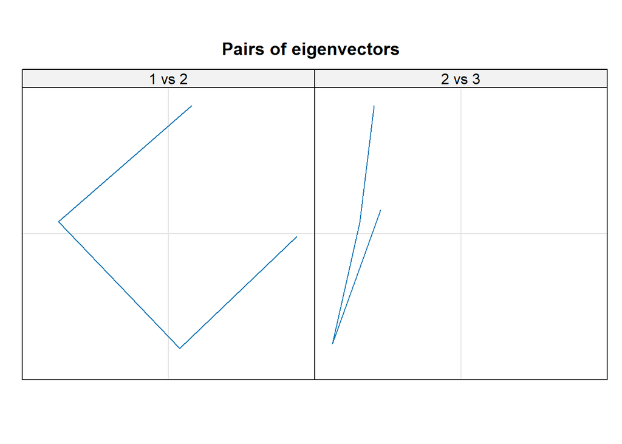

```r
plot(s.TSExample, type='paired', idx=1:2, plot.contrib = FALSE)
```

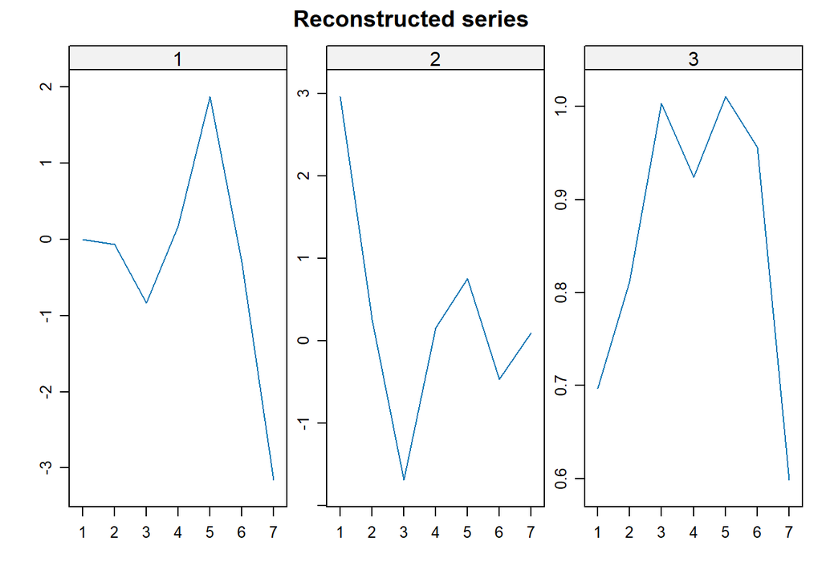

```r
plot(s.TSExample, type='series', groups=1:3)
```

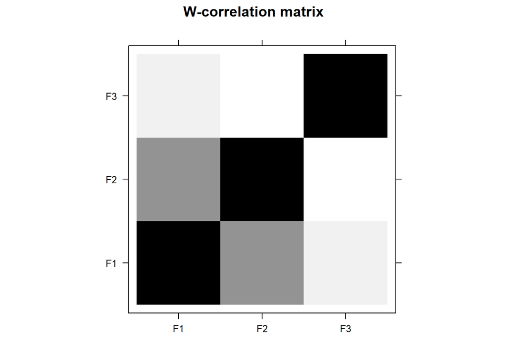

```r
plot(wcor(s.TSExample, groups=1:3))
```

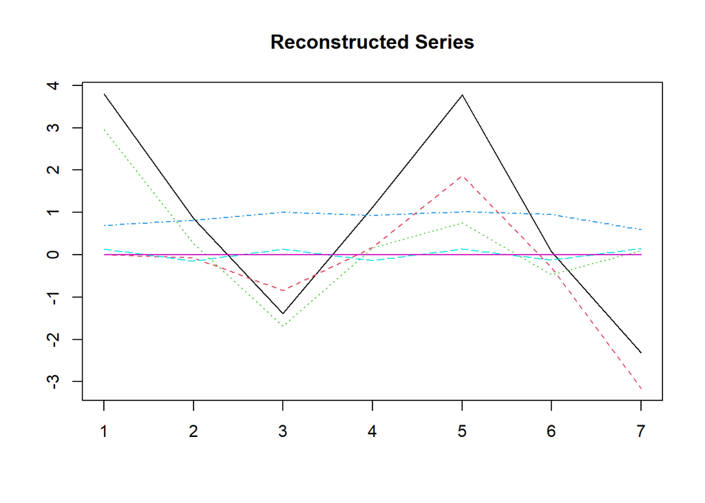

```r
plot(r.TSExample)
```

## Пример 2. Отсутствие разделимости

В случае, когда не выполняется слабая разделимость, представление временной ряд в виде суммы нескольких компонент ряда является невозможным.

Рассмотрим на простом примере:

Пусть дано два константных ряда. Если мы предполагаем, что они, по крайней мере, слабо разделимы, то по предложению 2.1, скалярное произведение произвольных отрезков длины L и K двух рядов должно быть равно нулю, другими словами, биортогональный базис первого ряда должен быть ортогонален биортогональному базису второго ряда, поскольку все элементы ряда образованы некоторым биортогональным базисом сингулярного значения

```r
ConstTS_One <- rep(2, 10)

ConstTS_Two <- rep(3, 10)

# Взяв произвольную длину окна 1 < L < 10

L <- 6
K <- 10 - L + 1

ConstTSValue <- c(ConstTS_One[2:(1+L)]%*%ConstTS_Two[4:(3+L)],
ConstTS_One[1:K]%*%ConstTS_Two[5:(4+K)])

#видим, что значения скалярное произведение любого отрезка ряда = 6L или
#6K != 0. Следовательно, константные ряды не могут быть отделимы друг от
#друга

# Конец задачи 1.
```

### Замечание: нужно доделать первую задачу через пакет Rssa.

# Задача 2.

На этом шаге обрабатывается таблица значений средних температур по месяцам. Столбцы - месяцы, строки - года. Чтобы построить временной ряд из таблицы нужно брать числа слева-направо (то есть, от января до декабря) и сверху-вниз (от ранних дат до поздних)

```r
spData <- read.table("SPData.txt", skip=5, col.names=c("Индекс ВМО", "Год", "Январь",
                                                       "Февраль", "Март", "Апрель",
                                                       "Май", "Июнь", "Июль", "Август",
                                                       "Сентябрь", "Октябрь", "Ноябрь",
                                                       "Декабрь"))


spDataVector <- scan("SPData.txt", skip = 5)
spDataVector <- spDataVector[!spDataVector %in% c(26063, 1805:2021)]
mspSSA <- ssa(spDataVector, L = 1296)
```

mspSSA

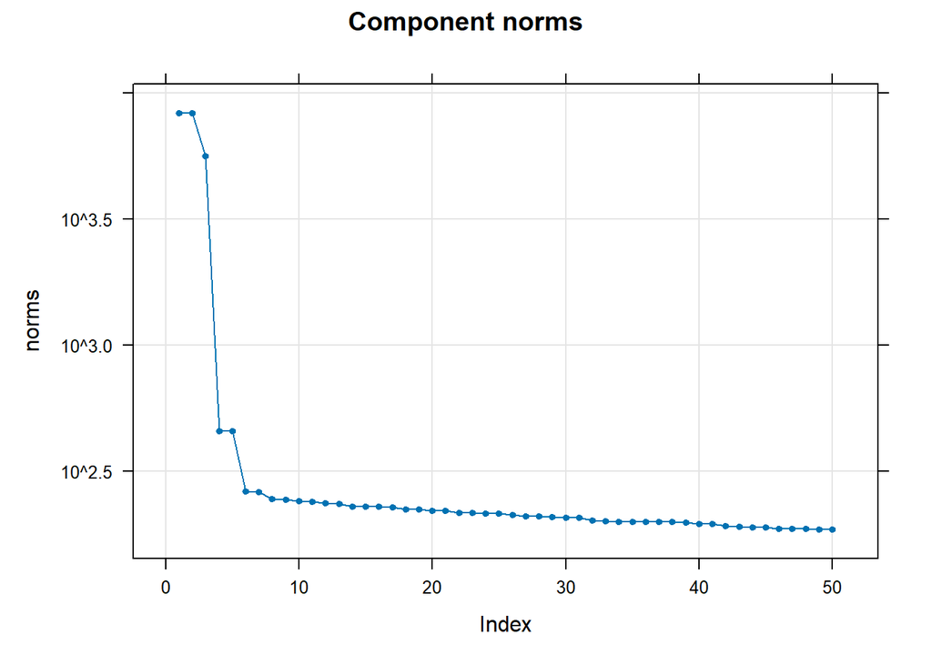

```r
plot(mspSSA)
```

```r
summary(mspSSA)
```

```
##
## Call:
## ssa(x = spDataVector, L = 1296)
##
## Series length: 2604, Window length: 1296,    SVD method: nutrlan
## Special triples:  0
##
## Computed:
## Eigenvalues: 50, Eigenvectors: 50,   Factor vectors: 0
##
## Precached: 0 elementary series (0 MiB)
##
## Overall memory consumption (estimate): 0.5172 MiB
```

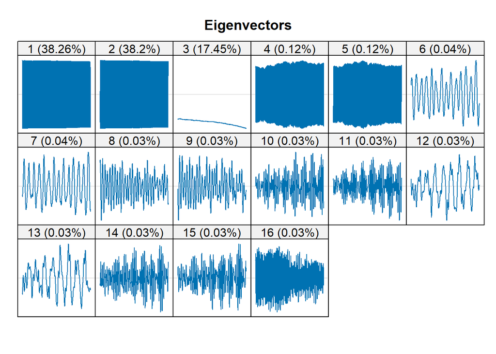

```r
plot(mspSSA, type='vectors', idx=1:16)
```

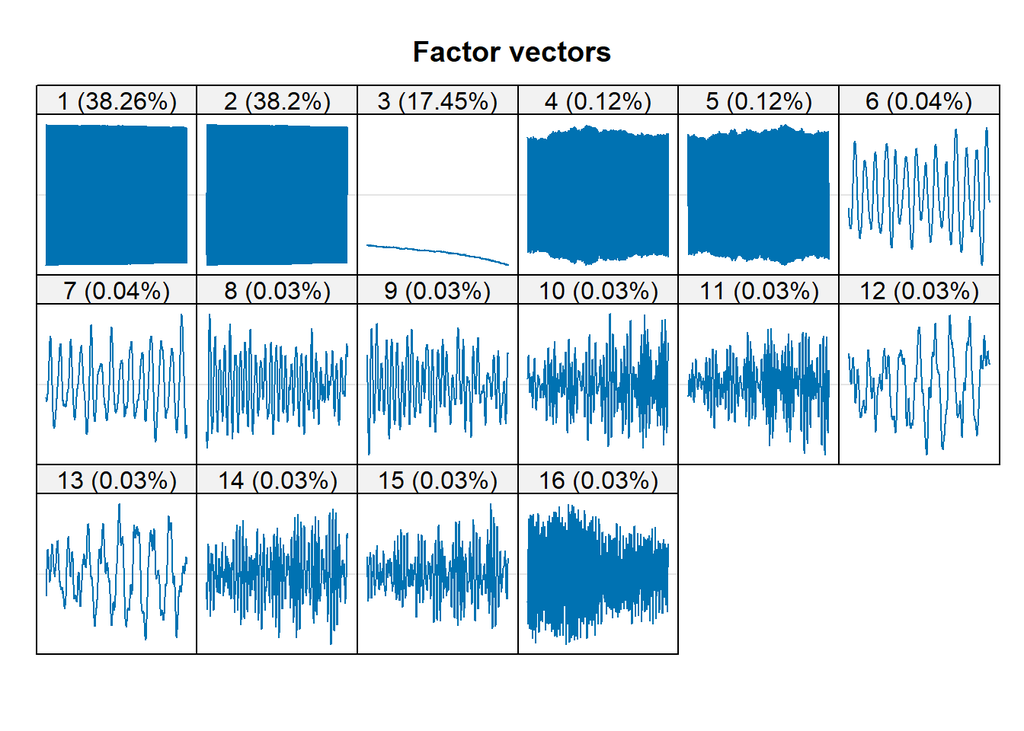

```r
plot(mspSSA, type='vectors', vectors='factor', idx=1:16)
```

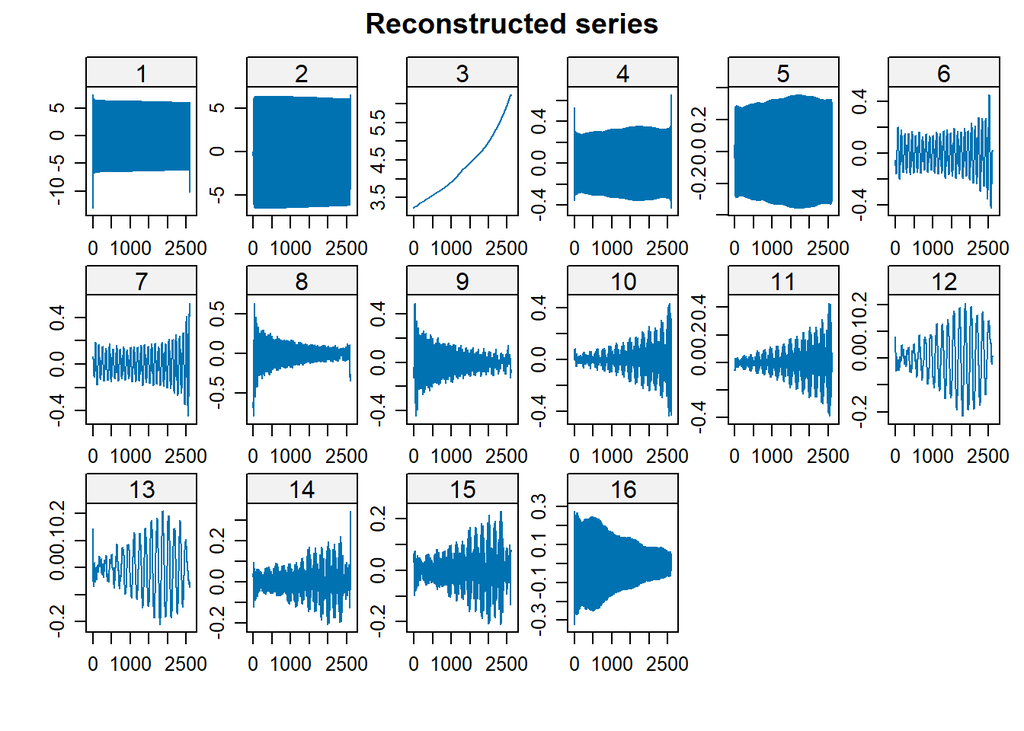

```r
plot(mspSSA, type='series', groups=1:16)
```

Поскольку длина окна близка к числу окон, то графики их собственных и факторных векторов совпадают. Первые две компоненты вносят наибольший вклад и, исходя из близости собственных чисел, являются колебаниями. Тоже самое можно сказать и про пары, идущие после 3-ей собственной тройки.

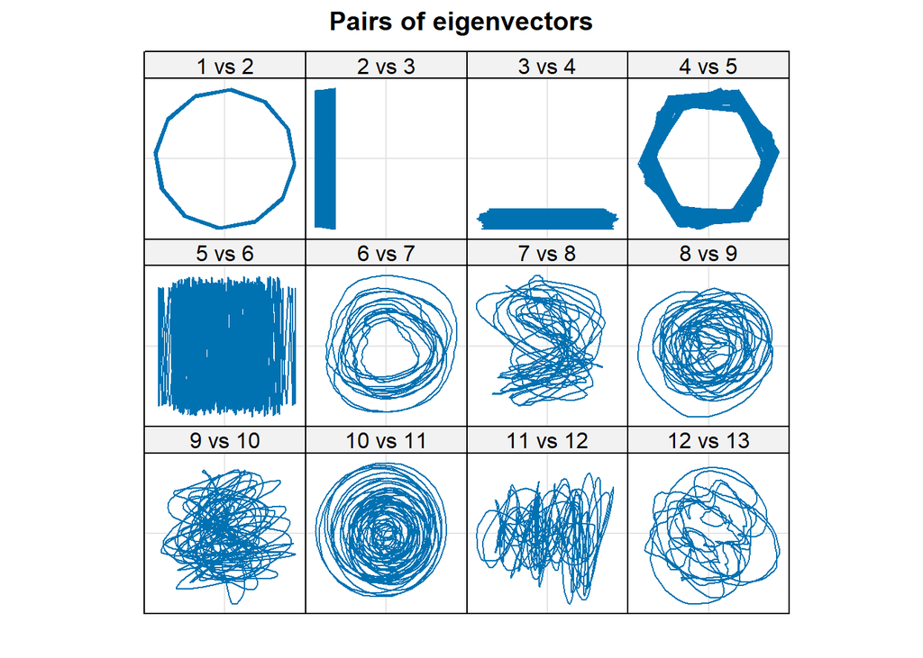

```r
plot(mspSSA, type="paired", idx=1:12, plot.contrib = FALSE)
```

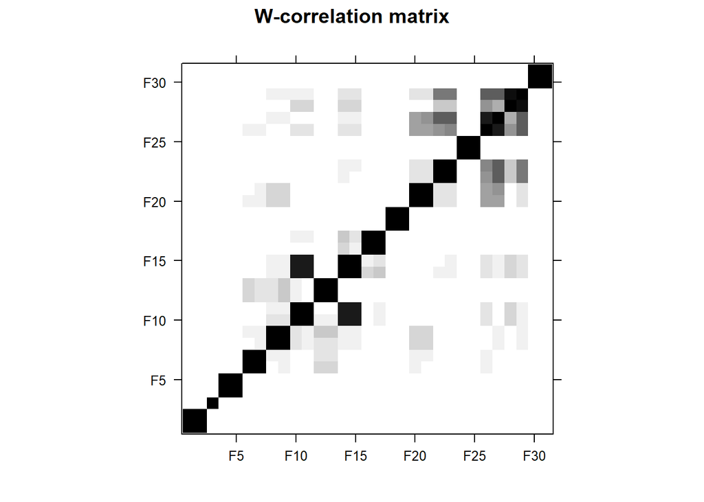

```r
plot(wcor(mspSSA, groups=1:31), scales=list(at=seq(5,30,5)))
```

### Восстановление утраченных действий

```r
s.mspSSA <- ssa(spDataVector , L=1296, neig=300)
g.mspSSA <- grouping.auto(s.mspSSA, base='series', freq.bins=c(0.1,0.2,0.3,0.4,+Inf))
r.mspSSA <- reconstruct(s.mspSSA, groups=list(Trend = 3, Seasonality=c(1:2,4:5,30:31)))
```

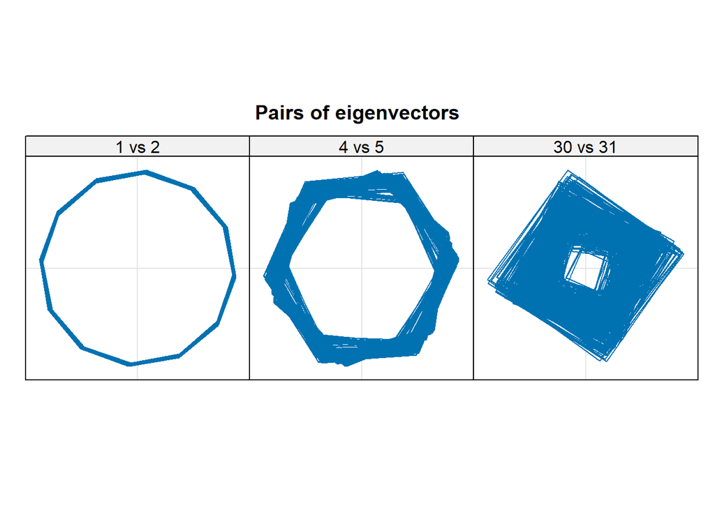

```r
plot(mspSSA, type='paired', idx=c(1,4,30), plot.contrib = FALSE)
```

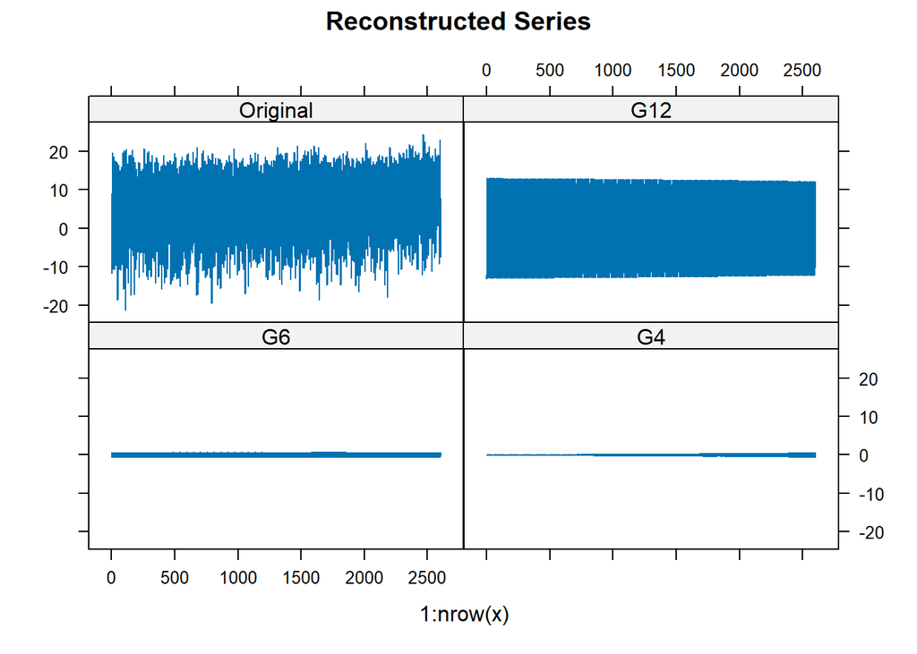

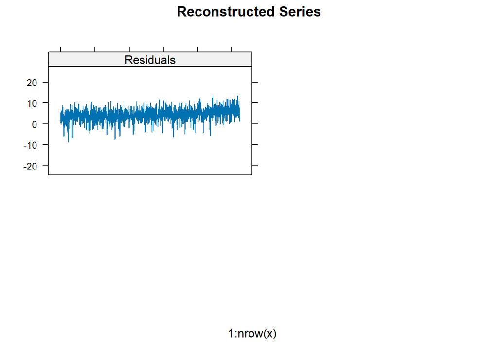

```r
plot(reconstruct(s.mspSSA, groups=list(G12=1:2, G6=4:5, G4=30:31)), plot.method="xyplot", layout=c(2,2))
```

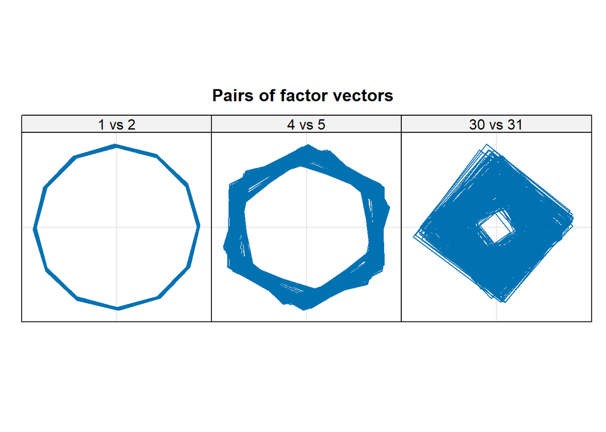

```r
plot(mspSSA, type='paired', vectors="factor", idx=c(1,4,30), plot.contrib = FALSE)
```

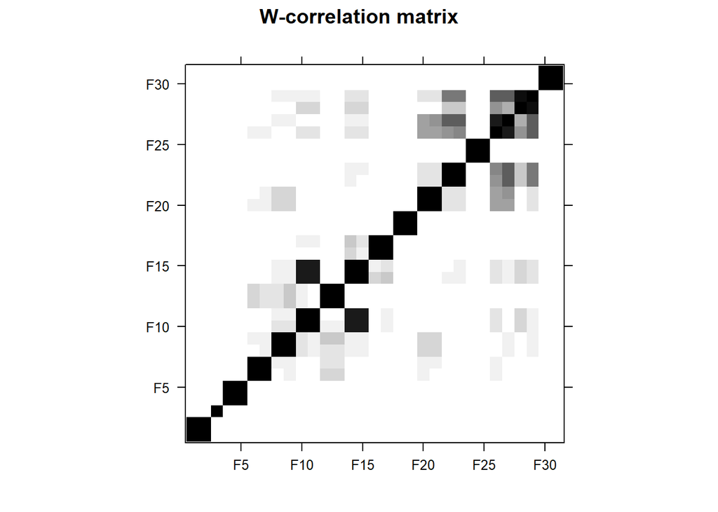

```r
plot(wcor(mspSSA,groups=1:31), scales=list(at=seq(5,30,5)))
```

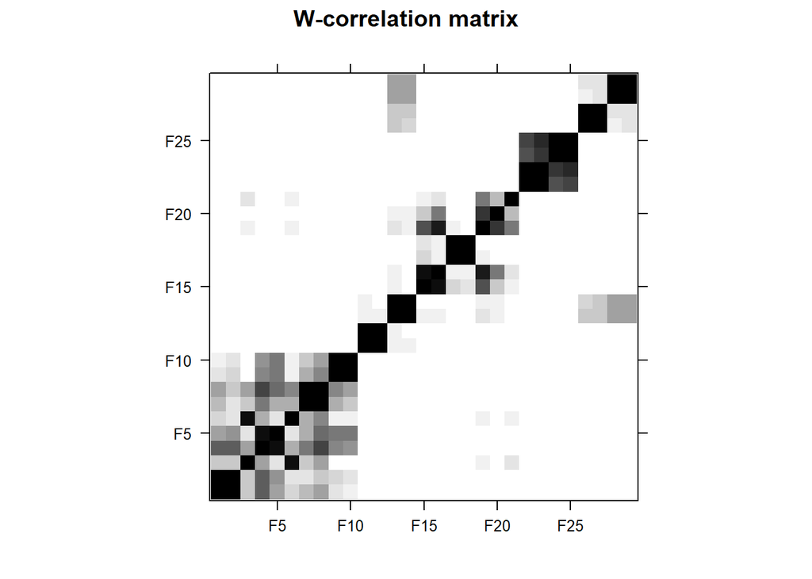

```r
plot(wcor(mspSSA,groups=32:60), scales=list(at=seq(5,25,5)))
```

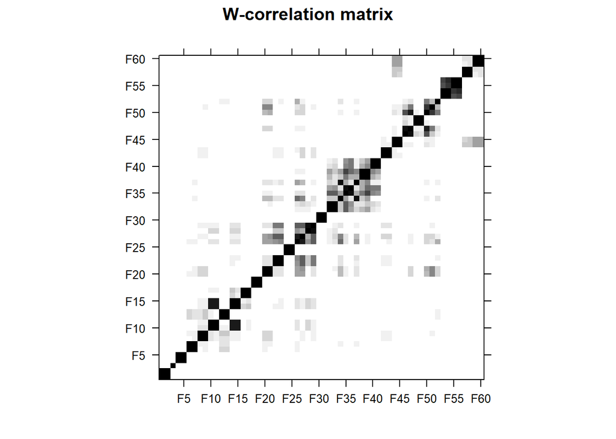

```r
plot(wcor(mspSSA, groups=1:60), scales=list(at=seq(5,60,5)))
```

```r
timecut <- window(spDataVector, end=time(spDataVector)[169])
```

```r
r.spTimecut <- reconstruct(s.mspSSA, groups=list(Trend=3, Seasonality=c(1:2,4:5,30:31)))
r.spTimecut$Trend <- r.spTimecut$Trend[1:241]
r.spTimecut$Seasonality <- r.spTimecut$Seasonality[1:241]

r.spTimecutSeason <- reconstruct(s.mspSSA, groups=list(G12=1:2, G6=4:5, G4=30:31))
r.spTimecutSeason$G12 <- r.spTimecutSeason$G12[1:241]
r.spTimecutSeason$G6 <- r.spTimecutSeason$G6[1:241]
r.spTimecutSeason$G4 <- r.spTimecutSeason$G4[1:241]
```

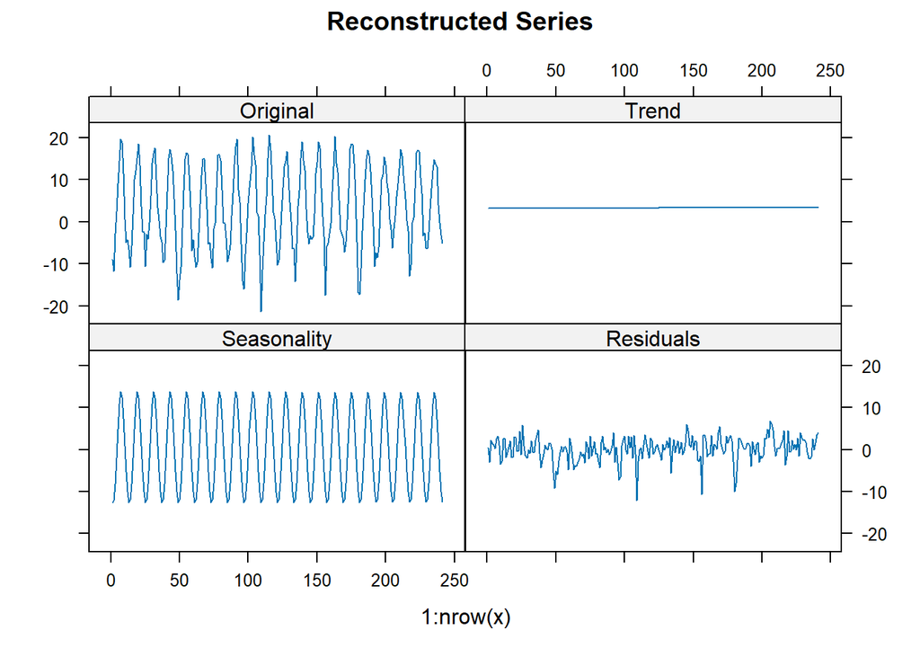

```r
plot(r.spTimecut, add.residuals=TRUE, add.original=TRUE, plot.method='xyplot', superpose=TRUE, layout=c(2,2))
```

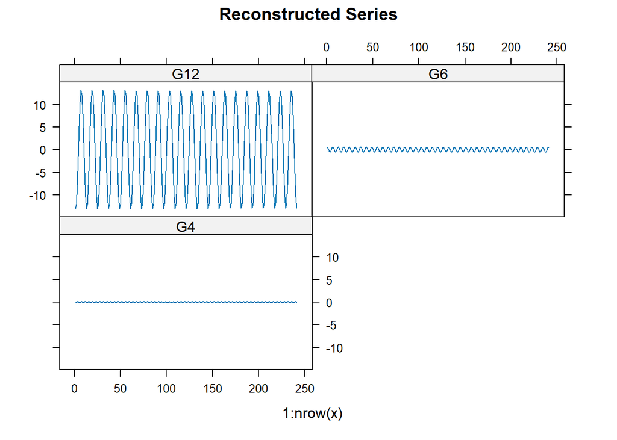

```r
plot(r.spTimecutSeason, add.residuals=FALSE, add.original=FALSE, plot.method='xyplot', superpose=TRUE, layout=c(2,2))
```

## Замечания

Денис, здравствуйте!

Сделано хорошо, видно, что разобрались.

Возникло несколько вопросов.

1. Первое — как каждый из графиков 1-3 показывает (подтверждает), что есть сильная разделимость? (у вас нет комментариев) +

## Примером отсутствия слабой разделимости может, вероятно, служить случай другой частоты, не 1/4? Две константы — вырожденный пример.

3. Про шум не поняла. Шум — случайная составляющая, для него теоретически вы не можете получить результат, но можете продемонстрировать, что при увеличении N точность выделения компонент возрастает. +

## В реальном примере: такой график плохо выглядит? https://ssa-with-r-book.github.io/01-chapter2-part1.html#produced-output

## Новые изменения

```r
library("Rssa")
data("AustralianWine", package = "Rssa")
fort <- window(AustralianWine, end = time(AustralianWine)[174])
fort<-fort[,"Fortified"]
```

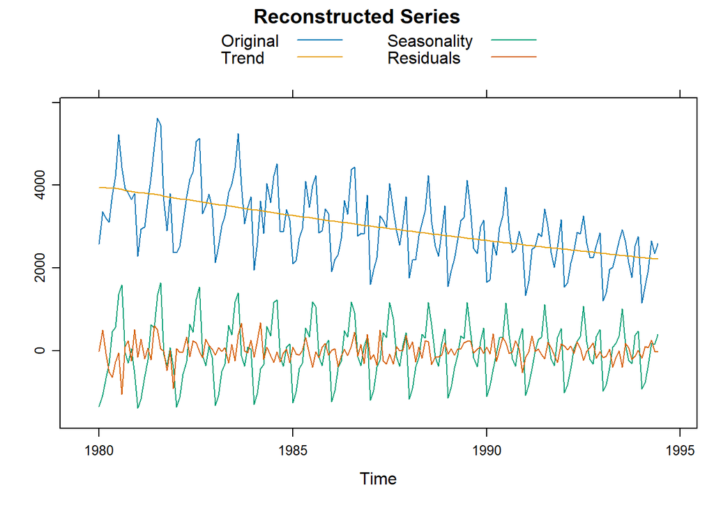

```r
s.fort <- ssa(fort, L = 84, kind = "1d-ssa")
r.fort <- reconstruct(s.fort,
                      groups = list(Trend = 1,
                                    Seasonality = 2:11))
plot(r.fort, add.residuals = TRUE, add.original = TRUE,
     plot.method = "xyplot",
     superpose = TRUE, auto.key = list(columns = 2))
```

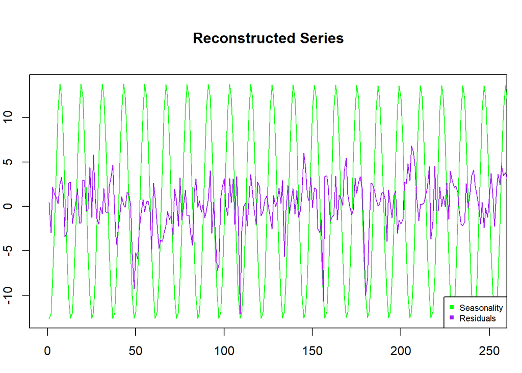

```r
s.mspSSA <- ssa(spDataVector , L=1296, neig=300)
r.mspSSA <- reconstruct(s.mspSSA, groups=list(Trend = 3, Seasonality=c(1:2,4:5,30:31)))
par(mar=c(3,2,5,1), xpd=FALSE)

plot(r.mspSSA, add.residuals=TRUE, add.original=FALSE, col=c('white', 'green', 'purple'), lty=c(0, 1, 1), xlim=c(0,250))

legend('bottomright', legend=c('Seasonality', 'Residuals'), pch=rep(15,4), col=c('green','purple'), cex=0.7)
```

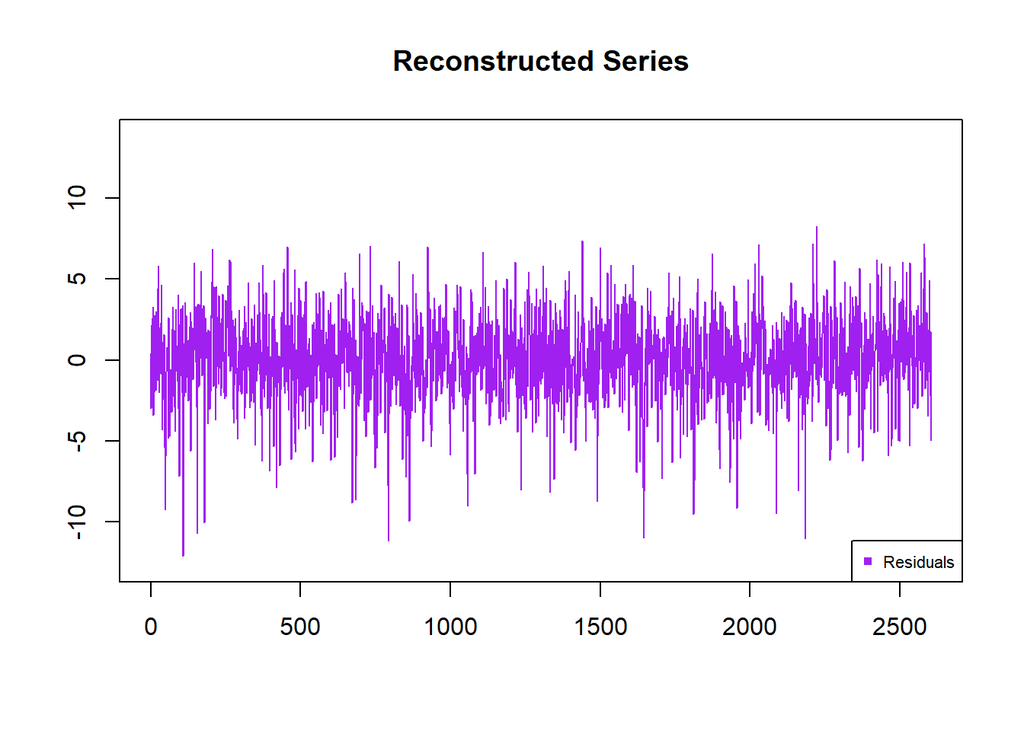

```r
plot(r.mspSSA, add.residuals=TRUE, add.original=FALSE, col=c('white', 'green', 'purple'), lty=c(0, 0, 1))

legend('bottomright', legend=c('Residuals'), pch=rep(15,4), col=c('purple'), cex=0.7)
```

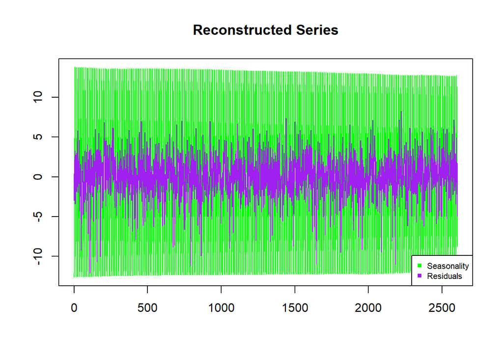

```r
plot(r.mspSSA, add.residuals=TRUE, add.original=FALSE, col=c('red', 'green', 'purple'), lty=c(0, 1, 1))

legend('bottomright', legend=c('Seasonality', 'Residuals'), pch=rep(15,2), col=c('green','purple'), cex=0.7)
```

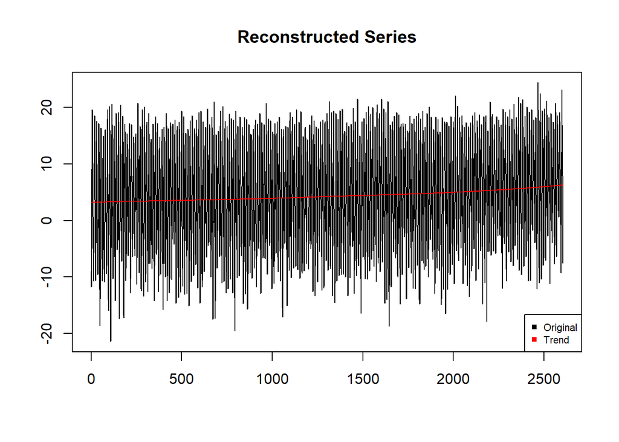

```r
plot(r.mspSSA, add.residuals=FALSE, add.original=TRUE, col=c('black', 'red', 'purple'), lty=c(1, 1, 0))

legend('bottomright', legend=c('Original', 'Trend'), pch=rep(15,3), col=c('black','red'), cex=0.7)
```

# Новые замечания (2)

Денис, здравствуйте!

Уточню:

1. в вашем дополнении в 2.1.2 при чем тут \omega \neq 1/N? (а почему там звездочки, а не просто номера формул — там же, если добавить новые номера, старые автоматически меняются?) +
2. я все же не поняла, а что вы понимаете под словом «шум», что значит, что пример с шумом, где он в описании? +
3. реальный пример — да, глобальное потепление видно. Случайная составляющая — это все кроме тренда и сезонности. На графике, где рисуете сезонность, имеет смысл рисовать случайную составляющую, чтобы сопоставить ее масштаб и масштаб сезонности, а также проверить, что остаток (случайная составляющая) колеблется вокруг нуля. +

НЭ

## Исправления: